# R Notebook midterm: 419 Survey of Multivariate Methods

## Distance Clusters

Select which “distance” form you are going to use: `d1` or `d2`.

```r
whichD = as.dist(d1); # convert matrix to dist "class"
```

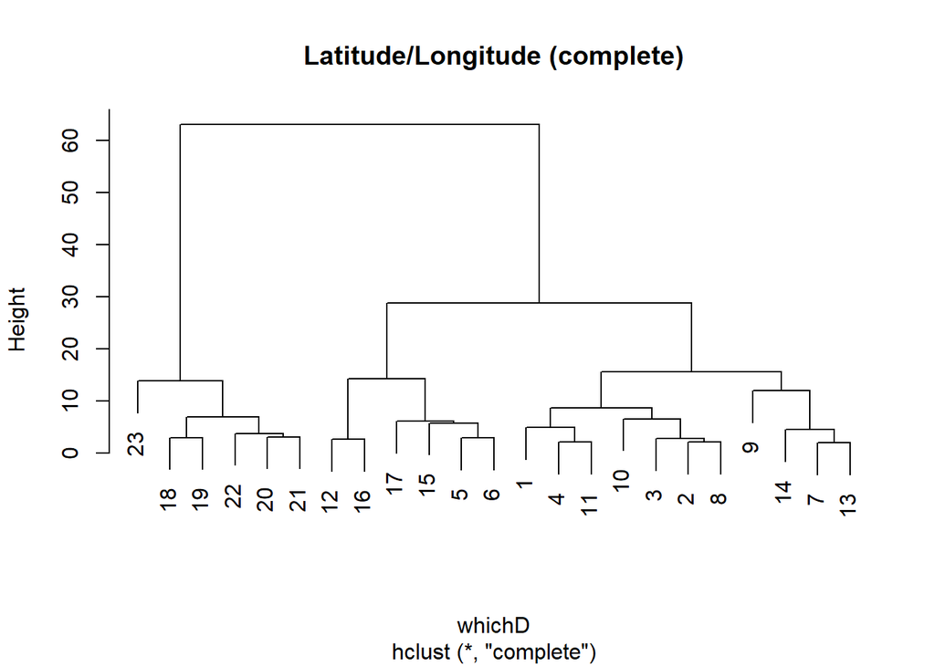

```r
latlon.hclust = hclust(whichD, method="complete");
plot(latlon.hclust, main="Latitude/Longitude (complete)");
```

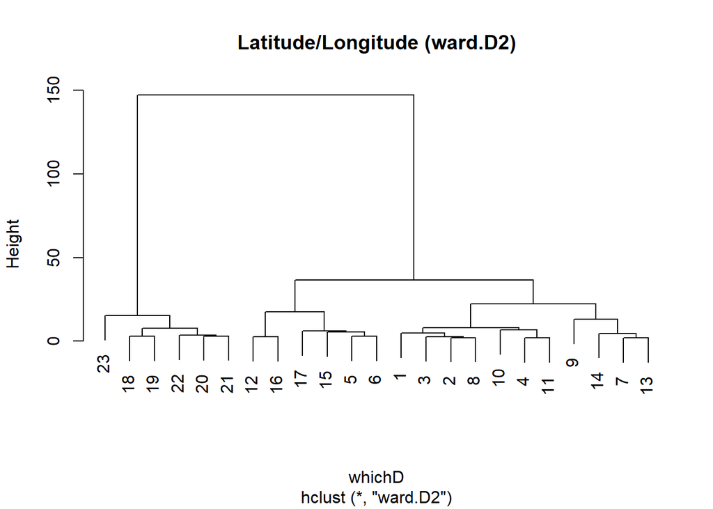

```r
latlon.hclust = hclust(whichD, method="ward.D2");
plot(latlon.hclust, main="Latitude/Longitude (ward.D2)");
```

### Student Response (5 points)

Why should you run these two different methods as suggested above?

[output not shown]

[This is worth 5 points. Length of the response should demonstrate your understanding of mastery. Too verbose is better than too succinct and references to “lecture” concepts or examples is a demonstration of mastery.]

Select how many clusters you think are in the data based on “longitude” and “latitude”.

```r
numberClusters = 3;
```